# Transformation of data

This problem is done to show that, even though data does not look like having an easy model to do the fit, after a small transformation it can be found.

```python
import numpy as np
import matplotlib.pylab as plt
from scipy.optimize import curve_fit
```

```python
url='https://raw.githubusercontent.com/jmsevillam/Herramientas-Computacionales-UniAndes/master/Data/Regression/spiral.dat'
```

```python
x,y,r, theta =np. genfromtxt ( url ).T
```

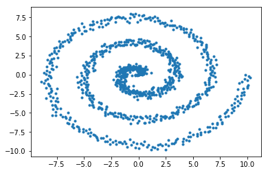

```python
plt.plot(x,y,'.')
```

The data gives the values of $r$ and $\\theta$, but in principle, they can be found from a transformation.

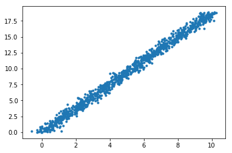

```python
plt.plot(r,theta,'.')
```

We will do the fit using

```python
def f(x,a,b):
    return a*x+b
```

```python
popt,pcov=curve_fit(f,r,theta)
```

Such that, after the fitting we get

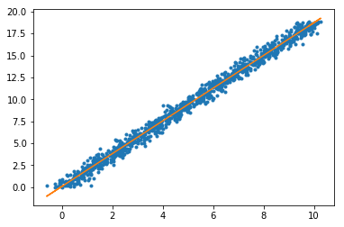

```python
plt.plot(r,theta,'.')
plt.plot(r,f(r,*popt))
```

So, as we want to recover the $x,y$ plane, we proceed to to a *resampling* so that the final result is smooth.

```python
r_plot=np.linspace(0,10,1000)
x_plot,y_plot=r_plot*np.cos(f(r_plot,*popt)),r_plot*np.sin(f(r_plot,*popt))
```

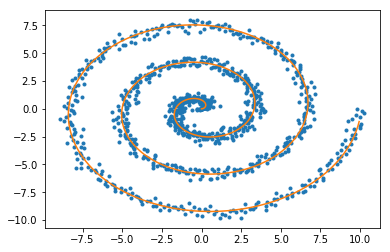

```python
plt.plot(x,y,'.')
plt.plot(x_plot,y_plot)
```

# Overfitting

One of the most important problems when learning to manage data, is that *description* is not *prediction*, so we will do a fit of a certain group of data, such that when we add a new point, it does not work as well as a simpler model.

```python
url='https://raw.githubusercontent.com/jmsevillam/Herramientas-Computacionales-UniAndes/master/Data/Regression/data.dat'
```

```python
x,y=np.genfromtxt(url).T
```

```python
x1=x[:-1]
y1=y[:-1]
```

Our two models

```python
def poly9 (x,a0 ,a1 ,a2 ,a3 ,a4 ,a5 ,a6 ,a7 ,a8 ,a9):
    return np. poly1d ([a0 ,a1 ,a2 ,a3 ,a4 ,a5 ,a6 ,a7 ,a8 ,a9])(x)
def line(x,a,b):
    return a*x+b
```

```python
print(len(y1))
```

```
10
```

As we have 10 points, we are using a 9th grade polynomial, so that it *touches* all the points.

The warning shown below is due to the fact that the method finds that the error is zero. (There is no distance between the line and the points)

```python
popt1 , pcov1 = curve_fit (line ,x1 ,y1)
popt2 , pcov2 = curve_fit (poly9 ,x1 ,y1)
```

```
C:\Users\jsevilla\AppData\Local\Continuum\anaconda3\lib\site-packages\scipy\optimize\minpack.py:794: OptimizeWarning: Covariance of the parameters could not be estimated
  category=OptimizeWarning)
```

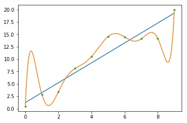

```python
x_plot =np. linspace (0 ,9 ,1000)
plt . plot (x_plot , line (x_plot ,* popt1 ))
plt . plot (x_plot , poly9 (x_plot ,* popt2 ))
plt . plot (x1 ,y1,'.')
```

But when we add a new point, the orange plot dows not describe the dataset anymore, but the blue one does.

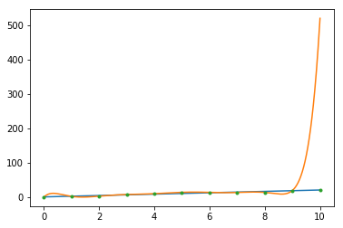

```python
x_plot2 =np. linspace (0 ,10 ,1000)
plt . plot (x_plot2 , line (x_plot2 ,* popt1 ))
plt . plot (x_plot2 , poly9 (x_plot2 ,* popt2 ))
plt . plot (x ,y,'.')
```

```python
popt3 , pcov3 = curve_fit (line ,x,y)
popt4 , pcov4 = curve_fit (poly9 ,x,y)
```

If we add the new point, and repeat the fit we get new values for the optimal parameters.

Let us see how different they are,

```python
for i in range(len(popt1)):
    print(popt1[i],popt3[i])
```

```
2.0070068176643754 2.002404037751126
1.2186629402930595 1.2324712800328053
```

```python
for i in range(len(popt2)):
    print(popt2[i],popt4[i])
```

```
0.0007582773494645842 6.993128355372365e-05
-0.031062001599914787 -0.0033470298885839183
0.5354718721067647 0.06703476040077067
-5.047269294749025 -0.7308349300533554
28.273770546993347 4.724757754896082
-95.64476841994585 -18.451825324898657
188.7946289546919 42.063461311916996
-195.3918116915053 -49.866684171791995
80.88774675459767 24.54508614817591
0.45282345061228935 0.4555279425159536
```

It is easier if we evaluate the percentage, (0 means that both are equal, and 1 means that the difference is of the 100%)

```python
for i in range(len(popt1)):
    print((popt1[i]-popt3[i])/popt1[i])
```

```
0.002293355395078193
-0.01133072918129859
```

```python
for i in range(len(popt2)):
    print((popt2[i]-popt4[i])/popt4[i])
```

```
9.84317791596159
8.28046734983197
6.9879732381442015
5.906168667089495
4.9841735838613825
4.183485467472099
3.4883284224925277
2.9182836183447756
2.2954761807022184
-0.0059370494128788
```

The linear model, remains close after the addition of the new point. But the Polynomial changes completely (Almost 10 times!!!)

# Fitting a Gaussian

```python
url='raw.githubusercontent.com/jmsevillam/Herramientas-Computacionales-UniAndes/master/Data/Spectra/137Cs_10min.dat'
```

```python
data=np.genfromtxt(url)
```

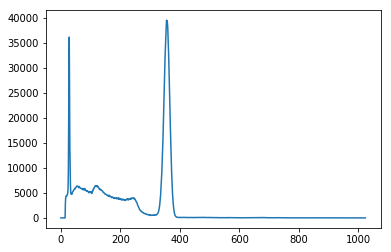

```python
plt.plot(data[:,0],data[:,1])
```

We select a fraction of the data.

```python
New_x=data[280:400,0]
New_data=data[280:400,1]
```

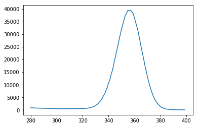

```python
plt.plot(New_x,New_data)
```

We define the model: a gaussian + brackground.

```python
def Gaussian(x,mu,sigma,amp,a,b):
    return amp*np.exp(-0.5*(x-mu)**2/sigma**2)+a*x+b
```

```python
popt,pcov=curve_fit(Gaussian,New_data,New_x)
```

The model did not work

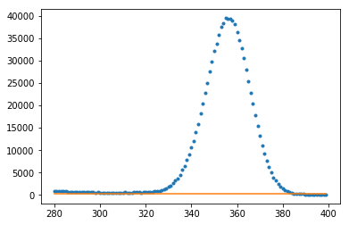

```python
plt.plot(New_x,New_data,'.')
plt.plot(New_x,Gaussian(New_x,*popt))
```

```python
popt,pcov=curve_fit(Gaussian,New_x,New_data,p0=[350,10,40000,1,1])
```

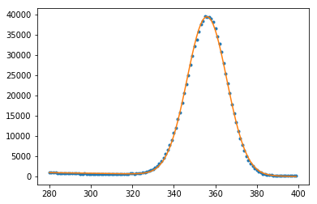

```python
plt.plot(New_x,New_data,'.')
plt.plot(New_x,Gaussian(New_x,*popt))
```